# Chapter 3

## 3.3 Treatment and treatment coverage

### Fig. 3.3.1 Estimated TB treatment coverage (new and relapse patients as a percentage of estimated TB incidence) in 2020, 30 high TB burden countries, WHO regions and globally

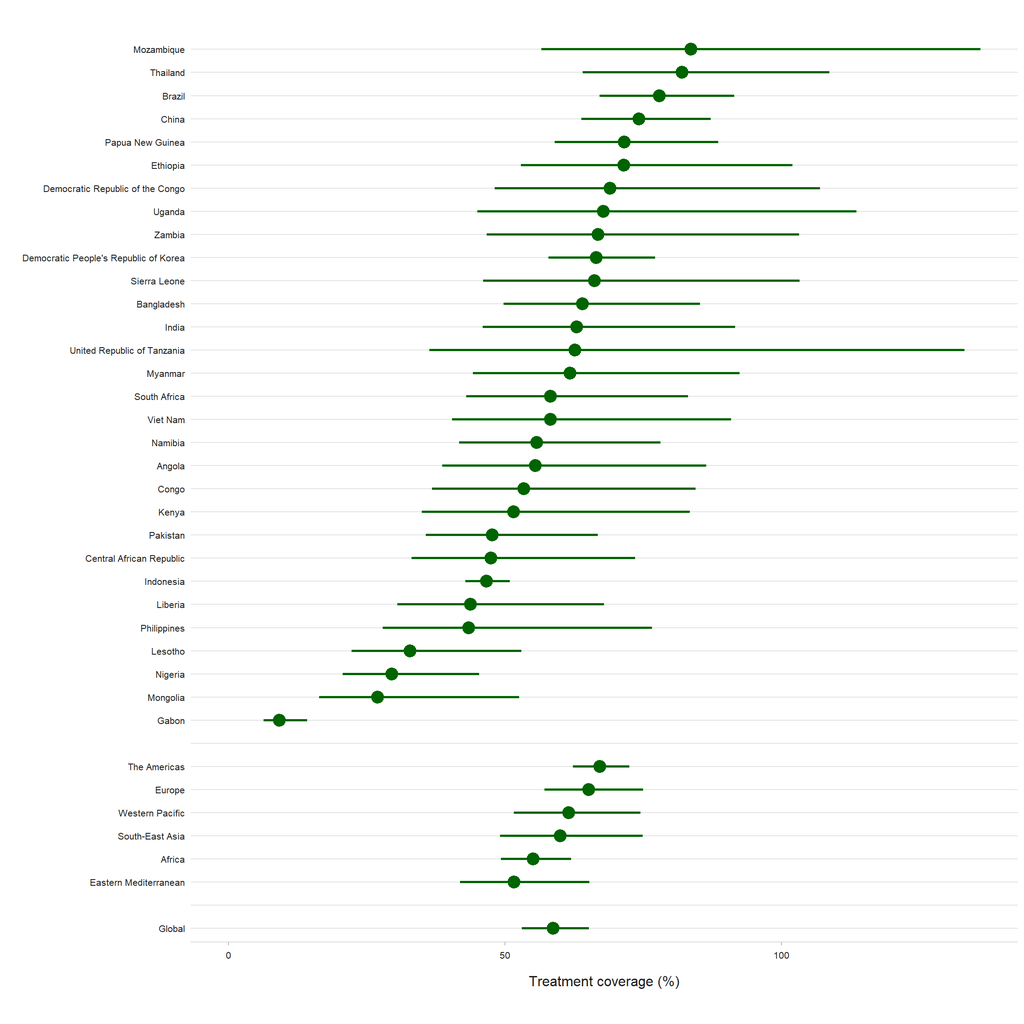

[figure not shown]

### Fig. 3.3.5 The global number of people reported to have been enrolled on treatment for MDR/RR-TB, 2015–2020

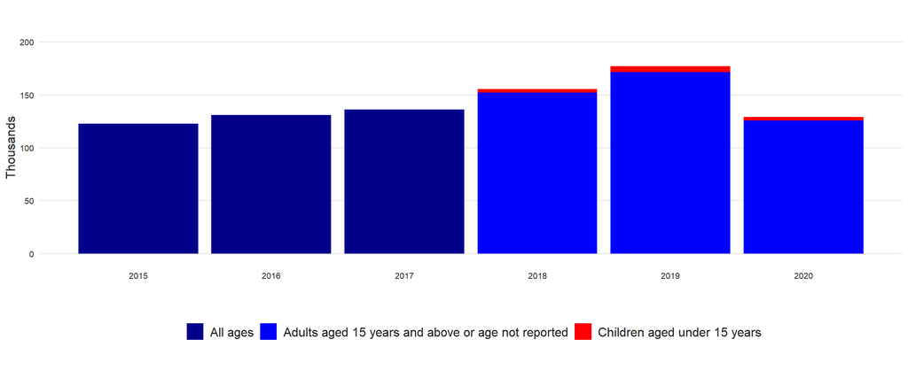

### Fig. 3.3.6 Estimated treatment coverage for MDR/RR-TB (patients started on treatment for MDR-TB as a percentage of the estimated incidence of MDR/RR-TB) in 2020, 30 high MDR-TB burden countries, WHO regions and globally

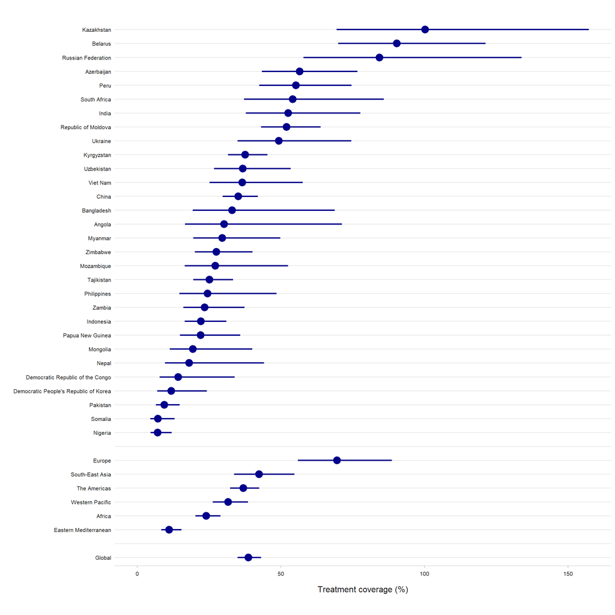

### Fig. 3.3.8 Countries that used bedaquiline for the treatment of MDR/XDR-TB as part of expanded access, compassionate use or under normal programmatic conditions by the end of 2020

**(HT: I changed the order of the next 3 maps to follow the order in the data collection form which was more logical)**

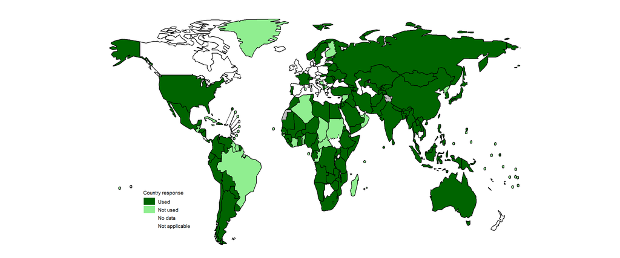

### Fig. 3.3.9 Countries that used all-oral longer MDR-TB treatment regimens by the end of 2020

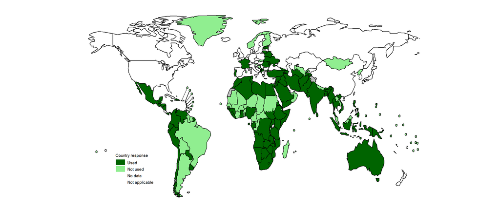

### Fig. 3.3.10 Countries that used shorter MDR-TB treatment regimens by the end of 2020

**(HT: I changed the title to reflect the revised question in the data collection form)**

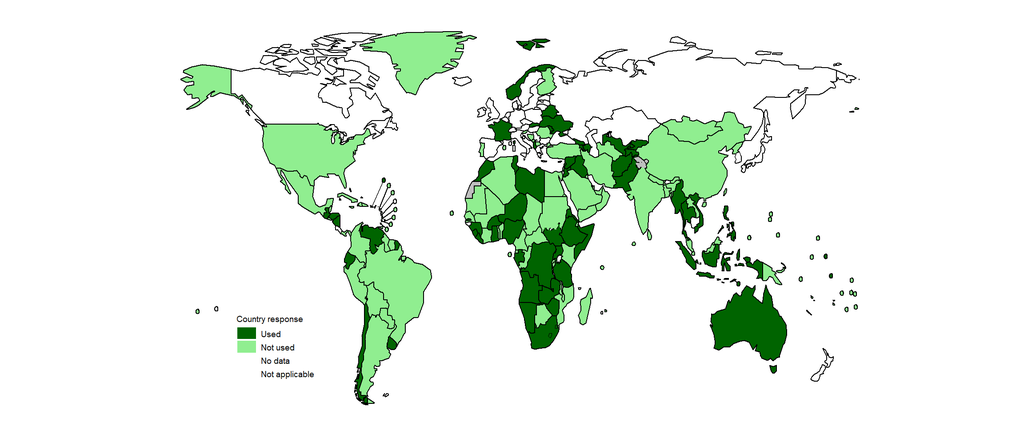

### Fig. 3.3.11 Number of patients with active follow up of adverse events as a proportion of patients enrolled on treatment for drug-resistant TB, 2020

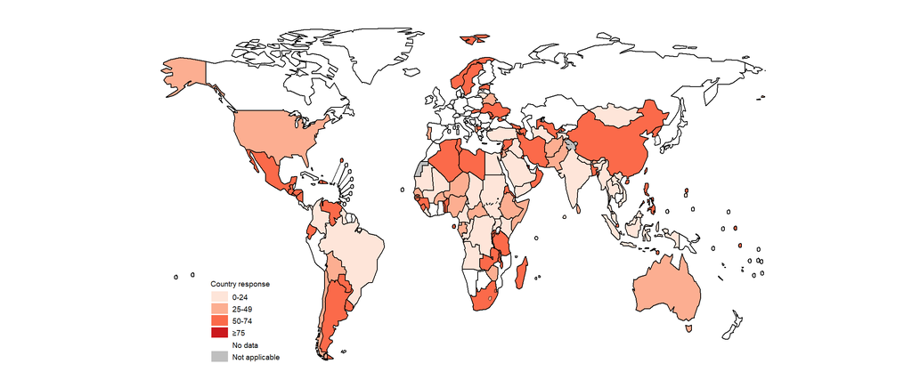

### Fig. 3.3.12 Estimated global number of incident HIV positive TB cases (red) compared with the global number of notified new and relapse TB cases known to be HIV-positive (black) and the global number of TB patients started on antiretroviral therapy (blue), 2004–2020. Shaded area represents uncertainty intervals.

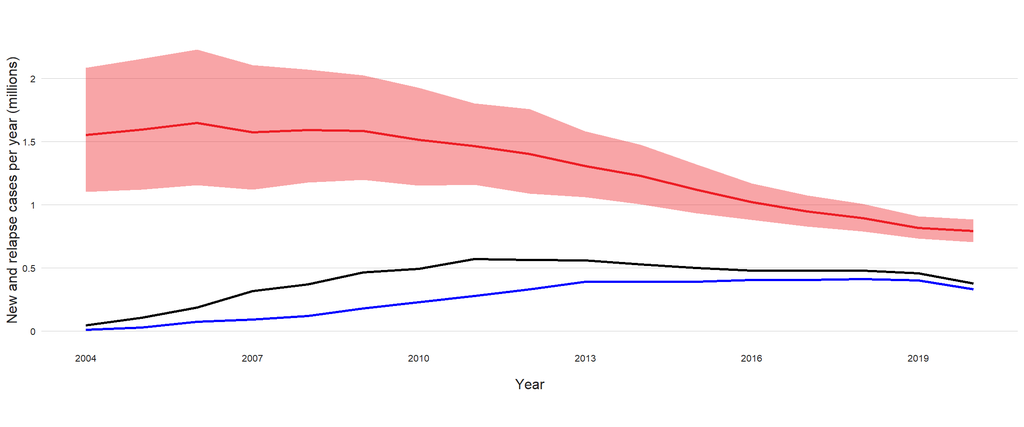

### Fig. 3.3.13 Estimated coverage of antiretroviral therapy for HIV-positive TB cases (HIV-positive TB patients on antiretroviral therapy as a percentage of the estimated incidence of HIV-positive TB) in 2020, 30 high TB/HIV burden countries, WHO regions and globally

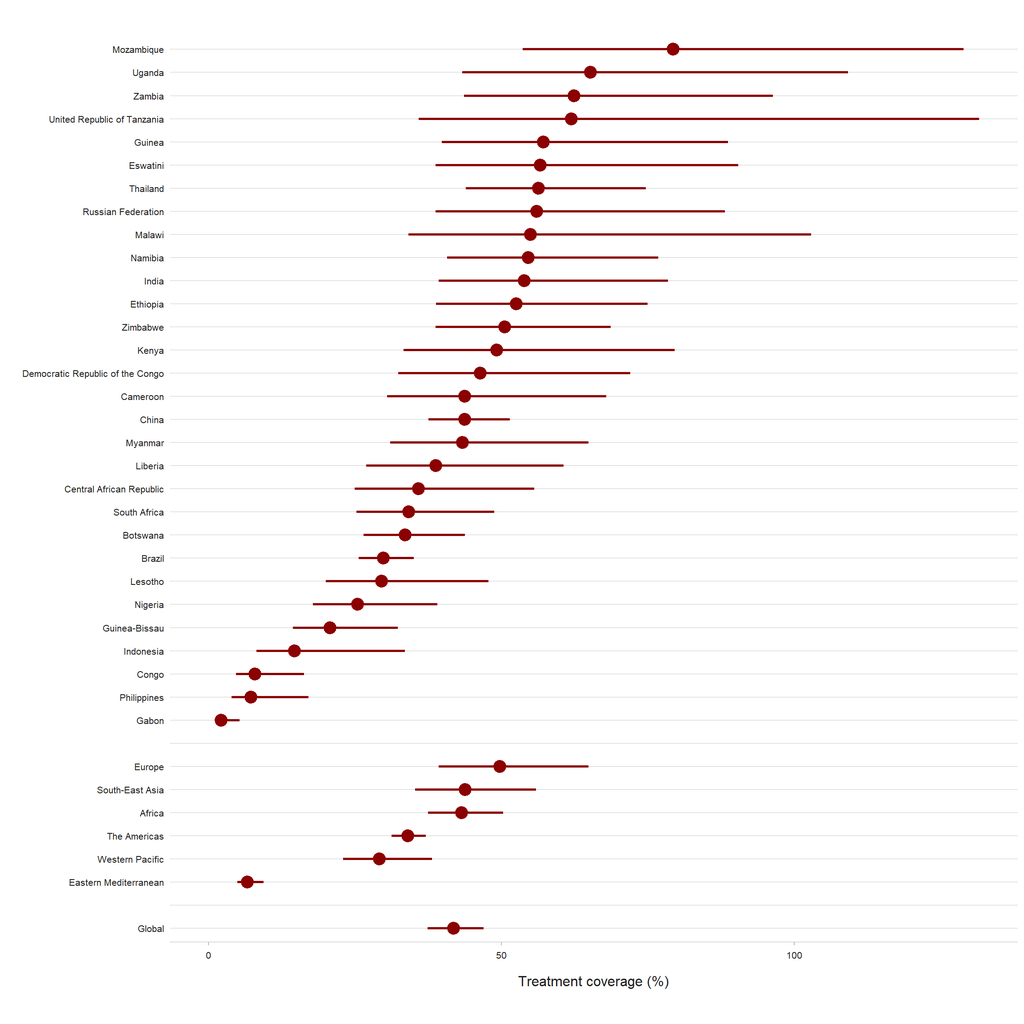